# Optimal Treatment Analysis

## Outcome Variable

**Outcome Variable:** ever_wasted

## Predictor Variables

**Intervention Variable:** single

**Adjustment Set:**

- arm
- W_mage
- meducyrs
- feducyrs
- W_mhtcm
- W_mwtkg
- W_mbmi
- delta_W_mage
- delta_meducyrs
- delta_feducyrs
- delta_W_mhtcm
- delta_W_mwtkg
- delta_W_mbmi

## Stratifying Variables

The analysis was stratified on these variable(s):

- agecat
- studyid
- country

## Data Summary

| agecat | studyid | country | single | ever_wasted | n_cell | n |
| --- | --- | --- | --- | --- | --- | --- |
| 0-24 months | ki0047075b-MAL-ED | BANGLADESH | 0 | 0 | 176 | 263 |
| 0-24 months | ki0047075b-MAL-ED | BANGLADESH | 0 | 1 | 87 | 263 |
| 0-24 months | ki0047075b-MAL-ED | BANGLADESH | 1 | 0 | 0 | 263 |
| 0-24 months | ki0047075b-MAL-ED | BANGLADESH | 1 | 1 | 0 | 263 |
| 0-24 months | ki0047075b-MAL-ED | BRAZIL | 0 | 0 | 182 | 233 |
| 0-24 months | ki0047075b-MAL-ED | BRAZIL | 0 | 1 | 15 | 233 |
| 0-24 months | ki0047075b-MAL-ED | BRAZIL | 1 | 0 | 32 | 233 |
| 0-24 months | ki0047075b-MAL-ED | BRAZIL | 1 | 1 | 4 | 233 |
| 0-24 months | ki0047075b-MAL-ED | INDIA | 0 | 0 | 132 | 249 |
| 0-24 months | ki0047075b-MAL-ED | INDIA | 0 | 1 | 117 | 249 |
| 0-24 months | ki0047075b-MAL-ED | INDIA | 1 | 0 | 0 | 249 |
| 0-24 months | ki0047075b-MAL-ED | INDIA | 1 | 1 | 0 | 249 |
| 0-24 months | ki0047075b-MAL-ED | NEPAL | 0 | 0 | 171 | 240 |
| 0-24 months | ki0047075b-MAL-ED | NEPAL | 0 | 1 | 69 | 240 |
| 0-24 months | ki0047075b-MAL-ED | NEPAL | 1 | 0 | 0 | 240 |
| 0-24 months | ki0047075b-MAL-ED | NEPAL | 1 | 1 | 0 | 240 |
| 0-24 months | ki0047075b-MAL-ED | PERU | 0 | 0 | 248 | 302 |
| 0-24 months | ki0047075b-MAL-ED | PERU | 0 | 1 | 20 | 302 |
| 0-24 months | ki0047075b-MAL-ED | PERU | 1 | 0 | 28 | 302 |
| 0-24 months | ki0047075b-MAL-ED | PERU | 1 | 1 | 6 | 302 |
| 0-24 months | ki0047075b-MAL-ED | SOUTH AFRICA | 0 | 0 | 143 | 312 |
| 0-24 months | ki0047075b-MAL-ED | SOUTH AFRICA | 0 | 1 | 33 | 312 |
| 0-24 months | ki0047075b-MAL-ED | SOUTH AFRICA | 1 | 0 | 108 | 312 |
| 0-24 months | ki0047075b-MAL-ED | SOUTH AFRICA | 1 | 1 | 28 | 312 |
| 0-24 months | ki0047075b-MAL-ED | TANZANIA, UNITED REPUBLIC OF | 0 | 0 | 222 | 261 |
| 0-24 months | ki0047075b-MAL-ED | TANZANIA, UNITED REPUBLIC OF | 0 | 1 | 29 | 261 |
| 0-24 months | ki0047075b-MAL-ED | TANZANIA, UNITED REPUBLIC OF | 1 | 0 | 7 | 261 |
| 0-24 months | ki0047075b-MAL-ED | TANZANIA, UNITED REPUBLIC OF | 1 | 1 | 3 | 261 |
| 0-24 months | ki1066203-TanzaniaChild2 | TANZANIA, UNITED REPUBLIC OF | 0 | 0 | 1643 | 2375 |
| 0-24 months | ki1066203-TanzaniaChild2 | TANZANIA, UNITED REPUBLIC OF | 0 | 1 | 508 | 2375 |

[output cut: 138 more lines]

The following strata were considered:

- agecat: 0-24 months, studyid: ki0047075b-MAL-ED, country: BANGLADESH
- agecat: 0-24 months, studyid: ki0047075b-MAL-ED, country: BRAZIL
- agecat: 0-24 months, studyid: ki0047075b-MAL-ED, country: INDIA
- agecat: 0-24 months, studyid: ki0047075b-MAL-ED, country: NEPAL
- agecat: 0-24 months, studyid: ki0047075b-MAL-ED, country: PERU
- agecat: 0-24 months, studyid: ki0047075b-MAL-ED, country: SOUTH AFRICA
- agecat: 0-24 months, studyid: ki0047075b-MAL-ED, country: TANZANIA, UNITED REPUBLIC OF
- agecat: 0-24 months, studyid: ki1066203-TanzaniaChild2, country: TANZANIA, UNITED REPUBLIC OF
- agecat: 0-24 months, studyid: ki1112895-Guatemala BSC, country: GUATEMALA
- agecat: 0-24 months, studyid: ki1119695-PROBIT, country: BELARUS
- agecat: 0-24 months, studyid: ki1126311-ZVITAMBO, country: ZIMBABWE
- agecat: 0-24 months, studyid: ki1135781-COHORTS, country: GUATEMALA
- agecat: 0-24 months, studyid: ki1135781-COHORTS, country: INDIA
- agecat: 0-24 months, studyid: ki1135781-COHORTS, country: PHILIPPINES
- agecat: 0-6 months, studyid: ki0047075b-MAL-ED, country: BANGLADESH
- agecat: 0-6 months, studyid: ki0047075b-MAL-ED, country: BRAZIL
- agecat: 0-6 months, studyid: ki0047075b-MAL-ED, country: INDIA
- agecat: 0-6 months, studyid: ki0047075b-MAL-ED, country: NEPAL
- agecat: 0-6 months, studyid: ki0047075b-MAL-ED, country: PERU
- agecat: 0-6 months, studyid: ki0047075b-MAL-ED, country: SOUTH AFRICA
- agecat: 0-6 months, studyid: ki0047075b-MAL-ED, country: TANZANIA, UNITED REPUBLIC OF
- agecat: 0-6 months, studyid: ki1066203-TanzaniaChild2, country: TANZANIA, UNITED REPUBLIC OF
- agecat: 0-6 months, studyid: ki1112895-Guatemala BSC, country: GUATEMALA
- agecat: 0-6 months, studyid: ki1119695-PROBIT, country: BELARUS
- agecat: 0-6 months, studyid: ki1126311-ZVITAMBO, country: ZIMBABWE
- agecat: 0-6 months, studyid: ki1135781-COHORTS, country: GUATEMALA
- agecat: 0-6 months, studyid: ki1135781-COHORTS, country: INDIA
- agecat: 0-6 months, studyid: ki1135781-COHORTS, country: PHILIPPINES
- agecat: 6-24 months, studyid: ki0047075b-MAL-ED, country: BANGLADESH
- agecat: 6-24 months, studyid: ki0047075b-MAL-ED, country: BRAZIL
- agecat: 6-24 months, studyid: ki0047075b-MAL-ED, country: INDIA
- agecat: 6-24 months, studyid: ki0047075b-MAL-ED, country: NEPAL
- agecat: 6-24 months, studyid: ki0047075b-MAL-ED, country: PERU
- agecat: 6-24 months, studyid: ki0047075b-MAL-ED, country: SOUTH AFRICA
- agecat: 6-24 months, studyid: ki0047075b-MAL-ED, country: TANZANIA, UNITED REPUBLIC OF
- agecat: 6-24 months, studyid: ki1066203-TanzaniaChild2, country: TANZANIA, UNITED REPUBLIC OF
- agecat: 6-24 months, studyid: ki1112895-Guatemala BSC, country: GUATEMALA
- agecat: 6-24 months, studyid: ki1119695-PROBIT, country: BELARUS
- agecat: 6-24 months, studyid: ki1126311-ZVITAMBO, country: ZIMBABWE
- agecat: 6-24 months, studyid: ki1135781-COHORTS, country: GUATEMALA
- agecat: 6-24 months, studyid: ki1135781-COHORTS, country: INDIA
- agecat: 6-24 months, studyid: ki1135781-COHORTS, country: PHILIPPINES

### Dropped Strata

Some strata were dropped due to rare outcomes:

- agecat: 0-24 months, studyid: ki0047075b-MAL-ED, country: BANGLADESH
- agecat: 0-24 months, studyid: ki0047075b-MAL-ED, country: BRAZIL
- agecat: 0-24 months, studyid: ki0047075b-MAL-ED, country: INDIA
- agecat: 0-24 months, studyid: ki0047075b-MAL-ED, country: NEPAL
- agecat: 0-24 months, studyid: ki0047075b-MAL-ED, country: TANZANIA, UNITED REPUBLIC OF
- agecat: 0-24 months, studyid: ki1112895-Guatemala BSC, country: GUATEMALA
- agecat: 0-24 months, studyid: ki1135781-COHORTS, country: INDIA
- agecat: 0-6 months, studyid: ki0047075b-MAL-ED, country: BANGLADESH
- agecat: 0-6 months, studyid: ki0047075b-MAL-ED, country: BRAZIL
- agecat: 0-6 months, studyid: ki0047075b-MAL-ED, country: INDIA
- agecat: 0-6 months, studyid: ki0047075b-MAL-ED, country: NEPAL
- agecat: 0-6 months, studyid: ki0047075b-MAL-ED, country: PERU
- agecat: 0-6 months, studyid: ki0047075b-MAL-ED, country: TANZANIA, UNITED REPUBLIC OF
- agecat: 0-6 months, studyid: ki1112895-Guatemala BSC, country: GUATEMALA
- agecat: 0-6 months, studyid: ki1135781-COHORTS, country: GUATEMALA
- agecat: 0-6 months, studyid: ki1135781-COHORTS, country: INDIA
- agecat: 6-24 months, studyid: ki0047075b-MAL-ED, country: BANGLADESH
- agecat: 6-24 months, studyid: ki0047075b-MAL-ED, country: BRAZIL
- agecat: 6-24 months, studyid: ki0047075b-MAL-ED, country: INDIA
- agecat: 6-24 months, studyid: ki0047075b-MAL-ED, country: NEPAL
- agecat: 6-24 months, studyid: ki0047075b-MAL-ED, country: PERU
- agecat: 6-24 months, studyid: ki0047075b-MAL-ED, country: TANZANIA, UNITED REPUBLIC OF
- agecat: 6-24 months, studyid: ki1112895-Guatemala BSC, country: GUATEMALA
- agecat: 6-24 months, studyid: ki1119695-PROBIT, country: BELARUS
- agecat: 6-24 months, studyid: ki1135781-COHORTS, country: INDIA

## Methods Detail

We’re interested in the causal parameters $E[Y_a]$ for all values of $a \in \mathcal{A}$. These parameters represent the mean outcome if, possibly contrary to fact, we intervened to set all units to have $A=a$. Under the randomization and positivity assumptions, these are identified by the statistical parameters $\psi_a=E_W[E_{Y|A,W}(Y|A=a,W)]$. In addition, we’re interested in the mean of $Y$, $E[Y]$ under no intervention (the observed mean). We will estimate these parameters by using SuperLearner to fit the relevant likelihood factors – $E_{Y|A,W}(Y|A=a,W)$ and $p(A=a|W)$, and then updating our likelihood fit using a joint TMLE.

For unadjusted analyses ($W=\{\}$), initial likelihoods were estimated using Lrnr_glm to estimate the simple $E(Y|A)$ and Lrnr_mean to estimate $p(A)$. For adjusted analyses, a small library containing Lrnr_glmnet, Lrnr_xgboost, and Lrnr_mean was used.

Having estimated these parameters, we will then use the delta method to estimate relative risks and attributable risks relative to a prespecified baseline level of $A$.

# Results Detail

## Results Plots

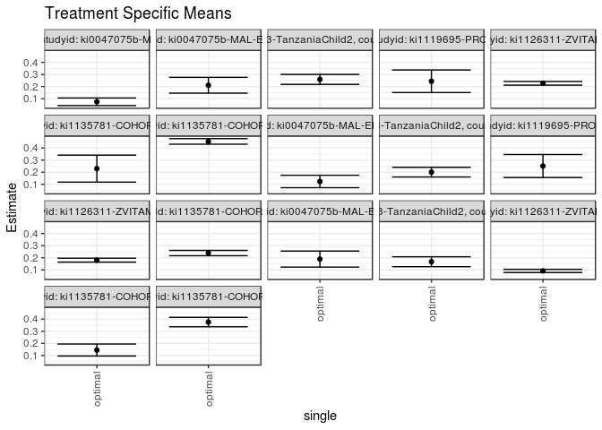

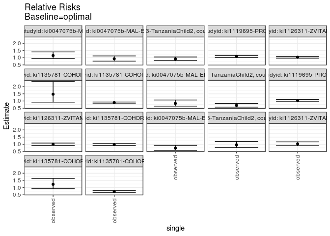

## Results Table

### Parameter: TSM

| agecat | studyid | country | intervention_level | baseline_level | estimate | ci_lower | ci_upper |
| --- | --- | --- | --- | --- | --- | --- | --- |
| 0-24 months | ki0047075b-MAL-ED | PERU | optimal | NA | 0.0747007 | 0.0431277 | 0.1062737 |
| 0-24 months | ki0047075b-MAL-ED | SOUTH AFRICA | optimal | NA | 0.2110130 | 0.1458620 | 0.2761641 |
| 0-24 months | ki1066203-TanzaniaChild2 | TANZANIA, UNITED REPUBLIC OF | optimal | NA | 0.2594600 | 0.2183404 | 0.3005796 |
| 0-24 months | ki1119695-PROBIT | BELARUS | optimal | NA | 0.2440474 | 0.1509892 | 0.3371056 |
| 0-24 months | ki1126311-ZVITAMBO | ZIMBABWE | optimal | NA | 0.2271302 | 0.2118942 | 0.2423662 |
| 0-24 months | ki1135781-COHORTS | GUATEMALA | optimal | NA | 0.2293245 | 0.1180889 | 0.3405602 |
| 0-24 months | ki1135781-COHORTS | PHILIPPINES | optimal | NA | 0.4538379 | 0.4309902 | 0.4766856 |
| 0-6 months | ki0047075b-MAL-ED | SOUTH AFRICA | optimal | NA | 0.1235711 | 0.0723402 | 0.1748021 |
| 0-6 months | ki1066203-TanzaniaChild2 | TANZANIA, UNITED REPUBLIC OF | optimal | NA | 0.2005093 | 0.1604355 | 0.2405831 |
| 0-6 months | ki1119695-PROBIT | BELARUS | optimal | NA | 0.2508367 | 0.1558717 | 0.3458017 |
| 0-6 months | ki1126311-ZVITAMBO | ZIMBABWE | optimal | NA | 0.1803925 | 0.1642309 | 0.1965541 |
| 0-6 months | ki1135781-COHORTS | PHILIPPINES | optimal | NA | 0.2390155 | 0.2172588 | 0.2607722 |
| 6-24 months | ki0047075b-MAL-ED | SOUTH AFRICA | optimal | NA | 0.1892926 | 0.1232022 | 0.2553830 |
| 6-24 months | ki1066203-TanzaniaChild2 | TANZANIA, UNITED REPUBLIC OF | optimal | NA | 0.1675073 | 0.1266727 | 0.2083419 |
| 6-24 months | ki1126311-ZVITAMBO | ZIMBABWE | optimal | NA | 0.0915536 | 0.0784750 | 0.1046322 |
| 6-24 months | ki1135781-COHORTS | GUATEMALA | optimal | NA | 0.1451790 | 0.0957884 | 0.1945697 |
| 6-24 months | ki1135781-COHORTS | PHILIPPINES | optimal | NA | 0.3757570 | 0.3369498 | 0.4145643 |

### Parameter: E(Y)

| agecat | studyid | country | intervention_level | baseline_level | estimate | ci_lower | ci_upper |
| --- | --- | --- | --- | --- | --- | --- | --- |
| 0-24 months | ki0047075b-MAL-ED | PERU | observed | NA | 0.0860927 | 0.0544044 | 0.1177810 |
| 0-24 months | ki0047075b-MAL-ED | SOUTH AFRICA | observed | NA | 0.1955128 | 0.1514355 | 0.2395901 |
| 0-24 months | ki1066203-TanzaniaChild2 | TANZANIA, UNITED REPUBLIC OF | observed | NA | 0.2370526 | 0.2199455 | 0.2541598 |
| 0-24 months | ki1119695-PROBIT | BELARUS | observed | NA | 0.2655346 | 0.1719990 | 0.3590703 |
| 0-24 months | ki1126311-ZVITAMBO | ZIMBABWE | observed | NA | 0.2344594 | 0.2274118 | 0.2415070 |
| 0-24 months | ki1135781-COHORTS | GUATEMALA | observed | NA | 0.3373494 | 0.2988711 | 0.3758277 |
| 0-24 months | ki1135781-COHORTS | PHILIPPINES | observed | NA | 0.4026622 | 0.3851243 | 0.4202002 |
| 0-6 months | ki0047075b-MAL-ED | SOUTH AFRICA | observed | NA | 0.1025641 | 0.0688457 | 0.1362825 |
| 0-6 months | ki1066203-TanzaniaChild2 | TANZANIA, UNITED REPUBLIC OF | observed | NA | 0.1393684 | 0.1254369 | 0.1532999 |
| 0-6 months | ki1119695-PROBIT | BELARUS | observed | NA | 0.2599065 | 0.1654090 | 0.3544039 |
| 0-6 months | ki1126311-ZVITAMBO | ZIMBABWE | observed | NA | 0.1806250 | 0.1742041 | 0.1870460 |
| 0-6 months | ki1135781-COHORTS | PHILIPPINES | observed | NA | 0.2336884 | 0.2185531 | 0.2488237 |
| 6-24 months | ki0047075b-MAL-ED | SOUTH AFRICA | observed | NA | 0.1389961 | 0.0967835 | 0.1812087 |
| 6-24 months | ki1066203-TanzaniaChild2 | TANZANIA, UNITED REPUBLIC OF | observed | NA | 0.1612581 | 0.1451483 | 0.1773679 |
| 6-24 months | ki1126311-ZVITAMBO | ZIMBABWE | observed | NA | 0.0940845 | 0.0885396 | 0.0996294 |
| 6-24 months | ki1135781-COHORTS | GUATEMALA | observed | NA | 0.1781076 | 0.1457776 | 0.2104376 |
| 6-24 months | ki1135781-COHORTS | PHILIPPINES | observed | NA | 0.2670270 | 0.2505637 | 0.2834903 |

### Parameter: RR

| agecat | studyid | country | intervention_level | baseline_level | estimate | ci_lower | ci_upper |
| --- | --- | --- | --- | --- | --- | --- | --- |
| 0-24 months | ki0047075b-MAL-ED | PERU | observed | optimal | 1.1525024 | 0.9442828 | 1.4066355 |
| 0-24 months | ki0047075b-MAL-ED | SOUTH AFRICA | observed | optimal | 0.9265438 | 0.7626455 | 1.1256651 |
| 0-24 months | ki1066203-TanzaniaChild2 | TANZANIA, UNITED REPUBLIC OF | observed | optimal | 0.9136385 | 0.7935021 | 1.0519636 |
| 0-24 months | ki1119695-PROBIT | BELARUS | observed | optimal | 1.0880452 | 1.0145850 | 1.1668243 |
| 0-24 months | ki1126311-ZVITAMBO | ZIMBABWE | observed | optimal | 1.0322687 | 0.9723187 | 1.0959151 |
| 0-24 months | ki1135781-COHORTS | GUATEMALA | observed | optimal | 1.4710567 | 0.9208697 | 2.3499607 |
| 0-24 months | ki1135781-COHORTS | PHILIPPINES | observed | optimal | 0.8872380 | 0.8480261 | 0.9282630 |
| 0-6 months | ki0047075b-MAL-ED | SOUTH AFRICA | observed | optimal | 0.8300007 | 0.6453329 | 1.0675127 |
| 0-6 months | ki1066203-TanzaniaChild2 | TANZANIA, UNITED REPUBLIC OF | observed | optimal | 0.6950721 | 0.5778421 | 0.8360853 |
| 0-6 months | ki1119695-PROBIT | BELARUS | observed | optimal | 1.0361580 | 0.9817701 | 1.0935589 |
| 0-6 months | ki1126311-ZVITAMBO | ZIMBABWE | observed | optimal | 1.0012890 | 0.9225131 | 1.0867918 |
| 0-6 months | ki1135781-COHORTS | PHILIPPINES | observed | optimal | 0.9777125 | 0.9159597 | 1.0436285 |
| 6-24 months | ki0047075b-MAL-ED | SOUTH AFRICA | observed | optimal | 0.7342925 | 0.5797137 | 0.9300892 |
| 6-24 months | ki1066203-TanzaniaChild2 | TANZANIA, UNITED REPUBLIC OF | observed | optimal | 0.9626930 | 0.7727162 | 1.1993767 |
| 6-24 months | ki1126311-ZVITAMBO | ZIMBABWE | observed | optimal | 1.0276443 | 0.9021109 | 1.1706462 |
| 6-24 months | ki1135781-COHORTS | GUATEMALA | observed | optimal | 1.2268134 | 0.9195531 | 1.6367420 |
| 6-24 months | ki1135781-COHORTS | PHILIPPINES | observed | optimal | 0.7106375 | 0.6447152 | 0.7833004 |

### Parameter: PAR

| agecat | studyid | country | intervention_level | baseline_level | estimate | ci_lower | ci_upper |
| --- | --- | --- | --- | --- | --- | --- | --- |
| 0-24 months | ki0047075b-MAL-ED | PERU | optimal | NA | 0.0113920 | -0.0039771 | 0.0267612 |
| 0-24 months | ki0047075b-MAL-ED | SOUTH AFRICA | optimal | NA | -0.0155002 | -0.0569874 | 0.0259869 |
| 0-24 months | ki1066203-TanzaniaChild2 | TANZANIA, UNITED REPUBLIC OF | optimal | NA | -0.0224073 | -0.0590241 | 0.0142094 |
| 0-24 months | ki1119695-PROBIT | BELARUS | optimal | NA | 0.0214872 | 0.0052957 | 0.0376788 |
| 0-24 months | ki1126311-ZVITAMBO | ZIMBABWE | optimal | NA | 0.0073292 | -0.0062609 | 0.0209193 |
| 0-24 months | ki1135781-COHORTS | GUATEMALA | optimal | NA | 0.1080249 | 0.0002285 | 0.2158212 |
| 0-24 months | ki1135781-COHORTS | PHILIPPINES | optimal | NA | -0.0511757 | -0.0710038 | -0.0313475 |
| 0-6 months | ki0047075b-MAL-ED | SOUTH AFRICA | optimal | NA | -0.0210070 | -0.0528817 | 0.0108677 |
| 0-6 months | ki1066203-TanzaniaChild2 | TANZANIA, UNITED REPUBLIC OF | optimal | NA | -0.0611409 | -0.0979920 | -0.0242898 |
| 0-6 months | ki1119695-PROBIT | BELARUS | optimal | NA | 0.0090698 | -0.0041611 | 0.0223007 |
| 0-6 months | ki1126311-ZVITAMBO | ZIMBABWE | optimal | NA | 0.0002325 | -0.0145491 | 0.0150142 |
| 0-6 months | ki1135781-COHORTS | PHILIPPINES | optimal | NA | -0.0053271 | -0.0209183 | 0.0102641 |
| 6-24 months | ki0047075b-MAL-ED | SOUTH AFRICA | optimal | NA | -0.0502965 | -0.0948594 | -0.0057335 |
| 6-24 months | ki1066203-TanzaniaChild2 | TANZANIA, UNITED REPUBLIC OF | optimal | NA | -0.0062492 | -0.0430924 | 0.0305940 |
| 6-24 months | ki1126311-ZVITAMBO | ZIMBABWE | optimal | NA | 0.0025309 | -0.0093986 | 0.0144605 |
| 6-24 months | ki1135781-COHORTS | GUATEMALA | optimal | NA | 0.0329286 | -0.0093675 | 0.0752246 |
| 6-24 months | ki1135781-COHORTS | PHILIPPINES | optimal | NA | -0.1087300 | -0.1444566 | -0.0730034 |

### Parameter: PAF

| agecat | studyid | country | intervention_level | baseline_level | estimate | ci_lower | ci_upper |
| --- | --- | --- | --- | --- | --- | --- | --- |
| 0-24 months | ki0047075b-MAL-ED | PERU | optimal | NA | 0.1323228 | -0.0590048 | 0.2890838 |
| 0-24 months | ki0047075b-MAL-ED | SOUTH AFRICA | optimal | NA | -0.0792798 | -0.3112252 | 0.1116363 |
| 0-24 months | ki1066203-TanzaniaChild2 | TANZANIA, UNITED REPUBLIC OF | optimal | NA | -0.0945248 | -0.2602361 | 0.0493968 |
| 0-24 months | ki1119695-PROBIT | BELARUS | optimal | NA | 0.0809206 | 0.0143753 | 0.1429729 |
| 0-24 months | ki1126311-ZVITAMBO | ZIMBABWE | optimal | NA | 0.0312600 | -0.0284694 | 0.0875206 |
| 0-24 months | ki1135781-COHORTS | GUATEMALA | optimal | NA | 0.3202165 | -0.0859299 | 0.5744610 |
| 0-24 months | ki1135781-COHORTS | PHILIPPINES | optimal | NA | -0.1270933 | -0.1792090 | -0.0772809 |
| 0-6 months | ki0047075b-MAL-ED | SOUTH AFRICA | optimal | NA | -0.2048183 | -0.5495877 | 0.0632430 |
| 0-6 months | ki1066203-TanzaniaChild2 | TANZANIA, UNITED REPUBLIC OF | optimal | NA | -0.4386996 | -0.7305766 | -0.1960502 |
| 0-6 months | ki1119695-PROBIT | BELARUS | optimal | NA | 0.0348963 | -0.0185684 | 0.0855545 |
| 0-6 months | ki1126311-ZVITAMBO | ZIMBABWE | optimal | NA | 0.0012874 | -0.0839954 | 0.0798606 |
| 0-6 months | ki1135781-COHORTS | PHILIPPINES | optimal | NA | -0.0227956 | -0.0917510 | 0.0418046 |
| 6-24 months | ki0047075b-MAL-ED | SOUTH AFRICA | optimal | NA | -0.3618551 | -0.7249893 | -0.0751656 |
| 6-24 months | ki1066203-TanzaniaChild2 | TANZANIA, UNITED REPUBLIC OF | optimal | NA | -0.0387527 | -0.2941362 | 0.1662336 |
| 6-24 months | ki1126311-ZVITAMBO | ZIMBABWE | optimal | NA | 0.0269006 | -0.1085111 | 0.1457710 |
| 6-24 months | ki1135781-COHORTS | GUATEMALA | optimal | NA | 0.1848801 | -0.0874847 | 0.3890302 |
| 6-24 months | ki1135781-COHORTS | PHILIPPINES | optimal | NA | -0.4071872 | -0.5510725 | -0.2766495 |